# Analysis of Variance

###### Navigation

- **Intro to R**
- **t-Test** [*t-Test example*]
- **Analysis of Variance (ANOVA)** [*ANOVA example*]
- **Chi Square** [*Chi Square example*]
- **Correlation** [*Correlation example*]
- **Regression** [*Regression example*]

### What is the Analysis of Variance (ANOVA)?

The ANOVA test examines the differences in means between **three or more** groups, in effort to see if the differences reflect true differences that we could expect to find in the population. The resulting test calculates an F value.

```r
library(MASS)
library(psych)
library(lattice)
library(mosaic)
#install.packages("gplots")
library(gplots)
library(stats)
```

#### Assumptions and Diagnostics for the ANOVA

The assumptions for an ANOVA are…

- Independence of Observations
- Equal Sample Sizes
- Homogeneity of Variance
- Normality

```r
data1 <- mtcars
```

##### 1. Independence of Observations (Examine Data Collection Strategy)

- Groups are not related or dependent upon each other. Case can’t be in more than one group. No ties between observations.

Examine data collection strategy to see if there are linkages between observations.

##### 2. Equal Sample Sizes (Examine N for each group)

- The number of cases in each group should be relatively similar. (If not, use pooled variance/unequal variances asssume t-test formula)

##### 3. Homogeneity of Variance (Examine SD<sup>2</sup> for each group)

- All groups have approximately equal variances (SD<sup>2</sup>). The distributions (or spread) for the groups are approximately equal. Keppel & Zedeck (1989) suggest that variance comparison should not exceed 10:1 ratio (*or… alternatively, the SDs, when compared, should not exceed around a 3:1 ratio*).

For both of the above assumptions, we can examine the univariate data table, broken out by group:

```r
describeBy(data1$mpg, data1$cyl)
```

```
##
##  Descriptive statistics by group
## group: 4
##    vars  n  mean   sd median trimmed  mad  min  max range skew kurtosis
## X1    1 11 26.66 4.51     26   26.44 6.52 21.4 33.9  12.5 0.26    -1.65
##      se
## X1 1.36
## --------------------------------------------------------
## group: 6
##    vars n  mean   sd median trimmed  mad  min  max range  skew kurtosis
## X1    1 7 19.74 1.45   19.7   19.74 1.93 17.8 21.4   3.6 -0.16    -1.91
##      se
## X1 0.55
## --------------------------------------------------------
## group: 8
##    vars  n mean   sd median trimmed  mad  min  max range  skew kurtosis
## X1    1 14 15.1 2.56   15.2   15.15 1.56 10.4 19.2   8.8 -0.36    -0.57
##      se
## X1 0.68
```

##### 4. Normality (Examine Plots: Histogram, Q-Q Normality Plots, Box-and-Whiskers Plots)

- Distribution must be relatively normal. (If violated, use “unequal variances assumed” formula, otherwise, use “equal variances assumed”)

##### 4a. Histogram

Plot the histogram for mpg (Y variable) broken out by number of cylinders in a car (levels of the X variable)…

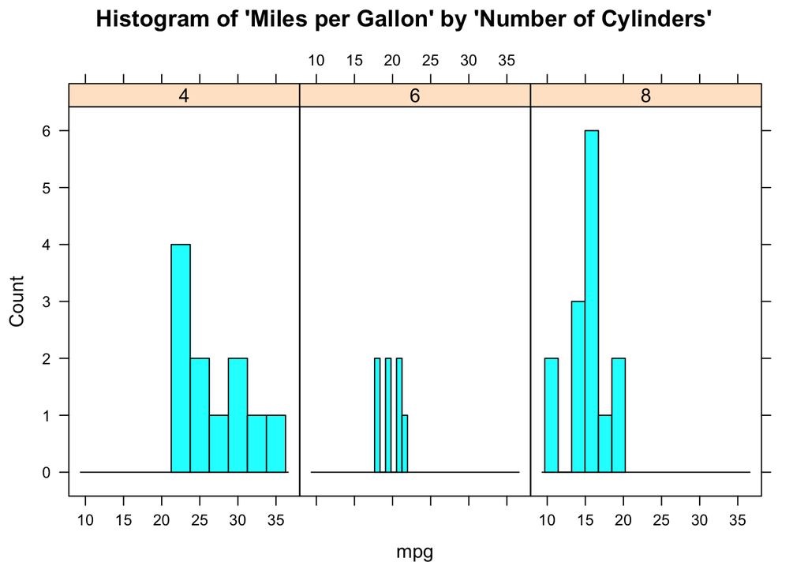

```r
histogram(~ mpg | factor(cyl), data = data1, type = "count", main = "Histogram of 'Miles per Gallon' by 'Number of Cylinders'")
```

…next, overlay a normal curve…

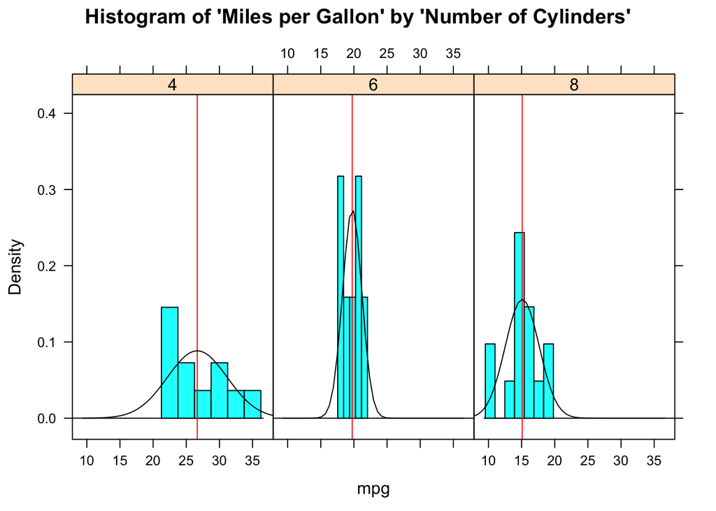

```r
histogram(~ mpg | factor(cyl), data = data1, main = "Histogram of 'Miles per Gallon' by 'Number of Cylinders'",
          type = "density",
          panel=function(x, ...) {
            panel.histogram(x, ...)
            panel.abline(v=mean(x, na.rm = TRUE),col="red")
            panel.mathdensity(dmath=dnorm, col="black",
                              args=list(mean=mean(x, na.rm = TRUE),
                                        sd=sd(x, na.rm = TRUE)), ...)
          })
```

##### 4b. Boxplots (Box-and-Whisker Plots)

Boxplots also provide a visual representation of the normality of a distribution. The boxplot has a box, a line through the box, two whiskers on either end of the box, and sometimes dots/points outside the whiskers. Below, we get a sense of what each part of the boxplot represents…

- Bottom (or left end) of the **whisker** represents the minimum score for that variable’s distribution
- Bottom (or left end) of the **box** represents the first quartile (the 25th percentile case)
- Middle line (or dot) inside the **box** represents the median, also known as the second quartile (the 50th percentile case)
- Top (or right end) of the **box** represents the third quartile (the 75th percentile case)
- Top (or right end) of the **whisker** represents the maximum score for that variable’s distribution
- Outside dots represent outliers - extreme high or extreme low values for that variable.

To tell if a variable is normally-distrubted using the box-and-whisker plot, generally, we want to see that there is *some* distance between the box and the end of the whiskers, that the box isn’t pushed too close to either whisker, that the median line (dot) is near the center of the box, and that there aren’t many outliers (dots) on the outside of the whiskers.

To plot a boxplot, broken out by *Number of Cylinders in a Car*, we can do the following…

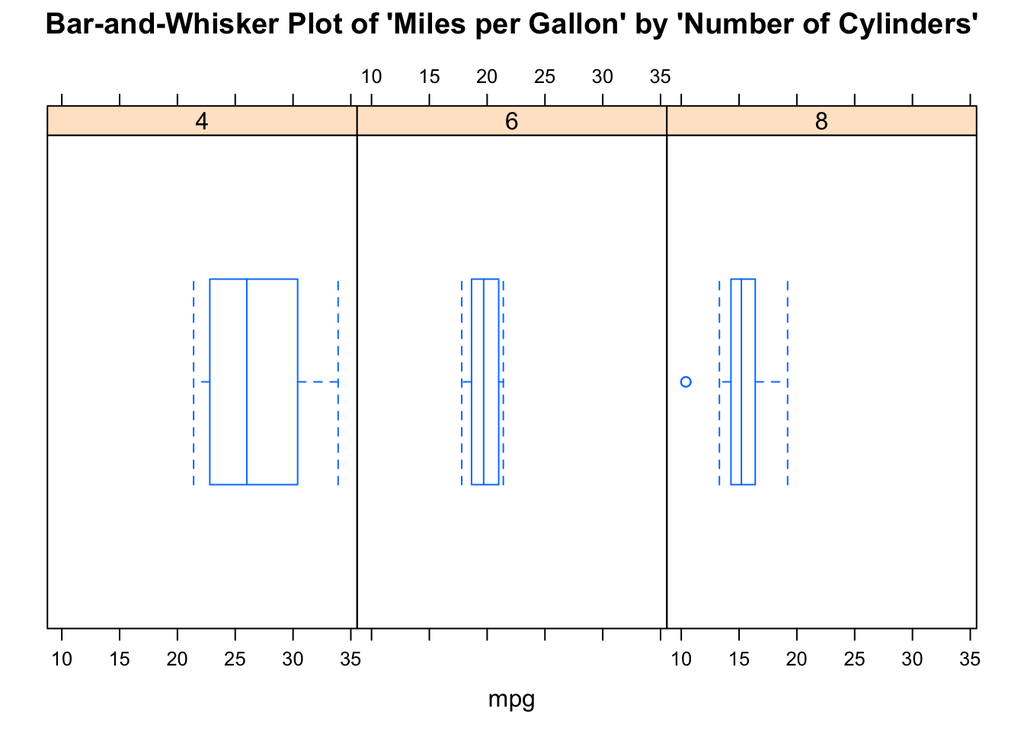

```r
bwplot(~mpg | factor(cyl), data = data1, pch="|", main = "Bar-and-Whisker Plot of 'Miles per Gallon' by 'Number of Cylinders'")
```

##### 4c. Normal Q-Q (Quantile-Quantile) Plots

The quantile-quantile plot is a visual tool to help us figure out if the empirical distribution of our variable fits (or rather, comes from) a theoretical normal distribution.

We assess normality an break this plot out by a grouping variable.

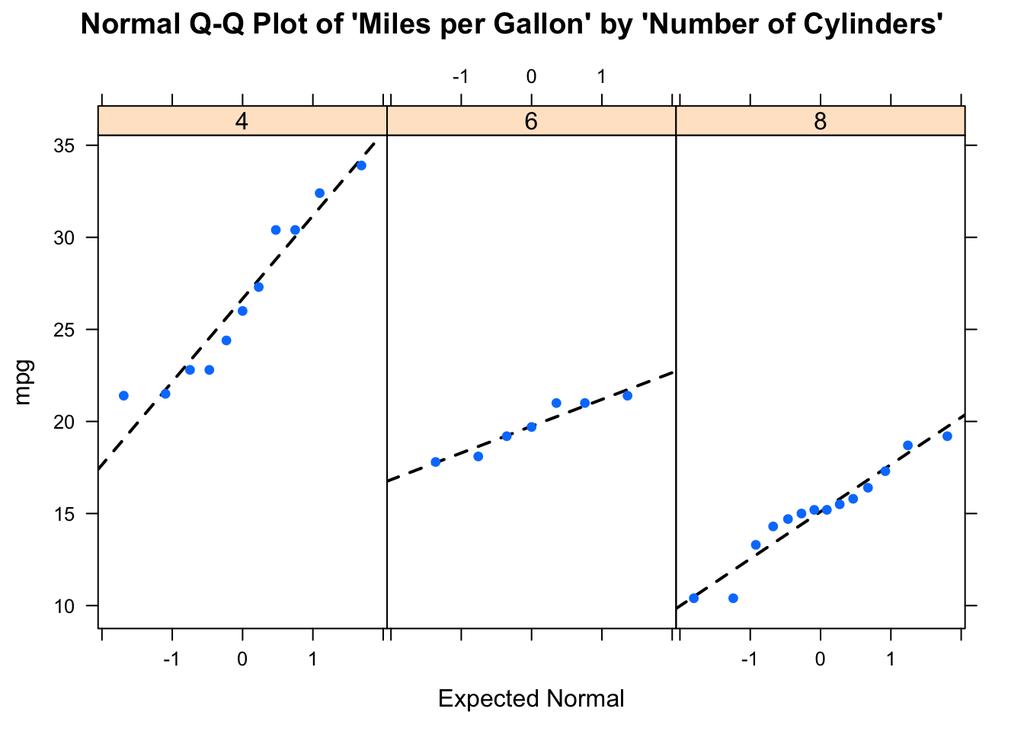

```r
xqqmath(~mpg | factor(cyl), data=data1, fitline = TRUE, main = "Normal Q-Q Plot of 'Miles per Gallon' by 'Number of Cylinders'", xlab = "Expected Normal")
```

### The ANOVA (F-Test)

The calculation for the F-Test is:

$F = \frac{{MS}_{between}}{{MS}_{within}} = \frac{\frac{{SS}_{between}}{df_{between}}}{\frac{{SS}_{within}}{df_{within}}}$

where…

- ${MS}_{between}$ is the mean square for the treatment, effect, or between groups
- ${MS}_{within}$ is the mean square for the error, or within groups
- ${SS}_{between} = \sum n_{group}(\bar{X}_{group} - \bar{X}_{total})^2$ is the sum of squares for the treatment, effect, or between groups; where $\bar{X}_{total}$ is the grand mean, or the mean of means
- ${SS}_{within} = \sum (X - \bar{X}_{group})^2$ is the square for the error, or within groups

In addition, the degrees of freedom ($df$) for the test is…  
$df_{between} = k - 1$; where $k$ is the number of groups $df_{within} = N - k$

### Running the ANOVA in R

To run the one-way ANOVA in R, we take the summary (output) of the analysis of variance `aov` function.

For the ANOVA, within the `aov` function, the dependent (interval-ratio level) variable is listed first and the independent (discrete/categorical) variable is listed second, separated by a tilde `~`.

```r
summary(aov(data1$mpg ~ data1$cyl))
```

```
##             Df Sum Sq Mean Sq F value   Pr(>F)
## data1$cyl    1  817.7   817.7   79.56 6.11e-10 ***
## Residuals   30  308.3    10.3
## ---
## Signif. codes:  0 '***' 0.001 '**' 0.01 '*' 0.05 '.' 0.1 ' ' 1
```

In the output above, we see the F-obtained value (79.56), the degrees of freedom between and within (1,30), and the p-value (6.11e-10, or .000000000611, which is much less than our set alpha level of .05).

To interpret the findings, we report the following information:

- The test used
- If you **reject** or **fail to reject** the null hypothesis
- The variables used in the analysis
- The degrees of freedom, calculated value of the test ($F_{obtained}$), and $p-value$
  - $F(df_{between},df_{within}) = F_{obtained}$, $p-value$

“Using a one-way ANOVA, I reject/fail to reject the null hypothesis that there is no mean difference between groups, in the population, $F(?) = ?, p ? .05$”

“Using one-way ANOVA, I reject the null hypothesis that there is no mean difference between the miles per gallon in cars with different cylinders, in the population, $F(1,30) = 79.56, p \leq .05$”

### Which means differ?

We can simply plot means, using the `plotmeans` function…

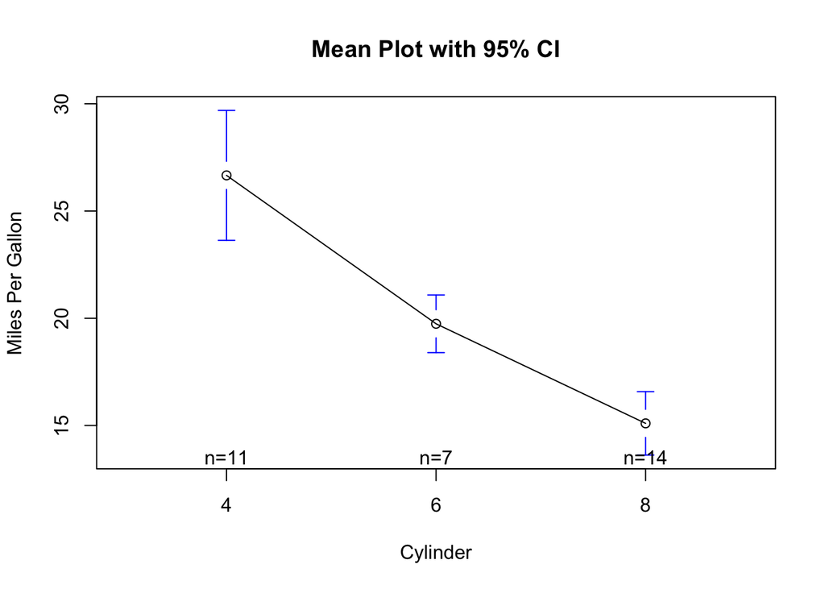

```r
plotmeans(mpg ~ cyl, data = data1,
          xlab = "Cylinder", ylab = "Miles Per Gallon",
          main="Mean Plot with 95% CI")
```

Here, we can see that it looks like 4-cylinder cars have extremely different (higher) mean mpgs than eith 6-cylinder or 8-cylinder cars.

And finally, we can see where the *significantly different* mean comparisons are, with the Tukey’s HSD test… using the `TukeyHSD` function…(here I had to call the second variable a factor because it is read by R as a number)

```r
TukeyHSD(aov(data1$mpg ~ factor(data1$cyl)))
```

```
##   Tukey multiple comparisons of means
##     95% family-wise confidence level
##
## Fit: aov(formula = data1$mpg ~ factor(data1$cyl))
##
## $`factor(data1$cyl)`
##           diff        lwr        upr     p adj
## 6-4  -6.920779 -10.769350 -3.0722086 0.0003424
## 8-4 -11.563636 -14.770779 -8.3564942 0.0000000
## 8-6  -4.642857  -8.327583 -0.9581313 0.0112287
```

Here, we see that 4-cylinder cars are, actually, significantly different than 6-cylinder or 8-cylinder cars, and that 6-cylinder cars are, themselves, significantly different from 8-cylinder cars.